# Random Forest: Initial Modelling Results

## Approach

The initial random forest uses the group’s unchanged `R/06_model_setup.R`, including the same provider-grouped training/test split and five validation folds. All recipe parameters and balanced class weights are estimated using the analysis portion of each fold only. No additional scaling is applied to the tree model.

Eight configurations compare mtry of 5 or 12, minimum node size of 5 or 20, and uniform or inverse-frequency class weights. Each forest contains 500 trees. The configuration with the highest mean validation macro-F1 is selected. This is a compact initial search, not an exhaustive optimisation.

## Cross-Validation Results

The selected configuration uses **mtry = 5**, **minimum node size = 20**, and **balanced weights**. Mean fold macro-F1 is **0.482**, with fold SD **0.027**. Mean fold accuracy is **63.0%**. For comparison, a training-fold majority classifier achieves mean macro-F1 **0.283** and mean accuracy **73.7%** on these same validation folds.

| candidate | mean_macro_f1 | sd_macro_f1 | mean_accuracy | mtry | min_node_size | weighting | num_trees |
| --- | --- | --- | --- | --- | --- | --- | --- |
| 7 | 0.482 | 0.027 | 0.630 | 5 | 20 | balanced | 500 |
| 5 | 0.478 | 0.017 | 0.682 | 5 | 5 | balanced | 500 |
| 8 | 0.477 | 0.028 | 0.645 | 12 | 20 | balanced | 500 |
| 6 | 0.461 | 0.015 | 0.712 | 12 | 5 | balanced | 500 |
| 2 | 0.419 | 0.013 | 0.742 | 12 | 5 | uniform | 500 |
| 4 | 0.407 | 0.012 | 0.743 | 12 | 20 | uniform | 500 |
| 1 | 0.401 | 0.018 | 0.747 | 5 | 5 | uniform | 500 |
| 3 | 0.400 | 0.015 | 0.749 | 5 | 20 | uniform | 500 |

The following class metrics and confusion matrix pool all out-of-fold predictions for the selected configuration. Pooled metrics need not equal the average of fold metrics because fold sizes differ.

| class | support | precision | recall | f1 |
| --- | --- | --- | --- | --- |
| Below NQS | 1016 | 0.181 | 0.290 | 0.223 |
| Meeting NQS | 9954 | 0.821 | 0.674 | 0.740 |
| Above NQS | 2527 | 0.414 | 0.605 | 0.492 |

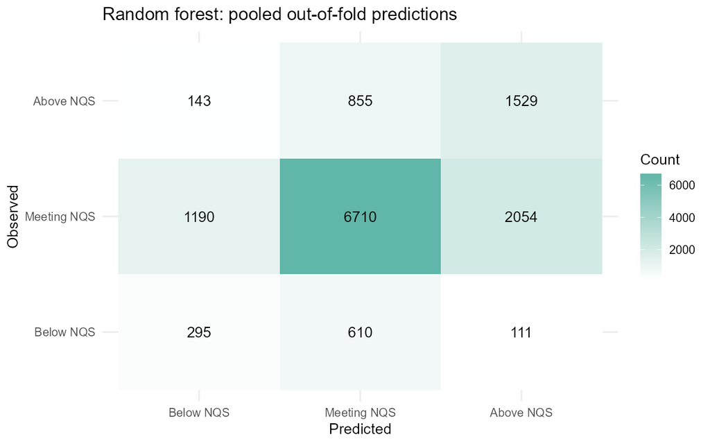

## Interpretation and Limitations

The selected model improves macro-F1 over the majority classifier, but sacrifices overall accuracy. This is consistent with the group’s choice to give each rating tier equal importance rather than optimise accuracy dominated by Meeting NQS. Below NQS remains difficult: its pooled recall is 29.0% and precision is 18.1%. This initial model therefore has substantial room for improvement and should be compared with the other classifiers using exactly the same grouped folds.

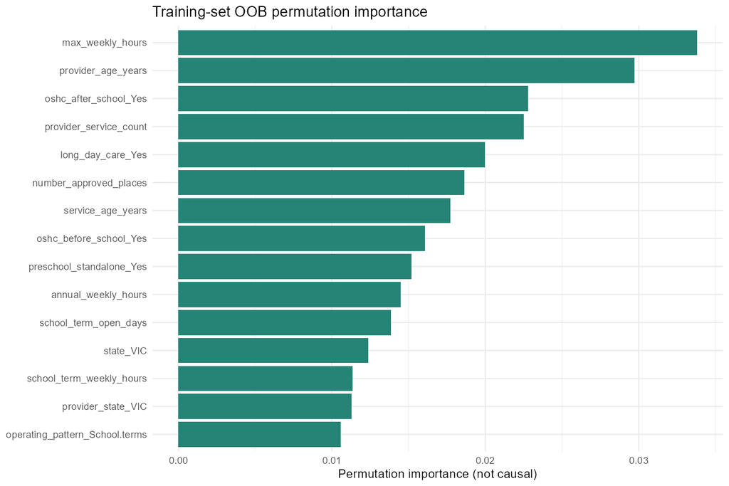

Importance is measured using out-of-bag permutation in the final training-set forest. It describes model reliance, not causation; correlated predictors can share or distort importance. OOB samples are not provider-grouped, so OOB results are not used as the model’s validation performance.

These CV results also selected the hyperparameters and may be optimistic; they are not independent test-set estimates. The held-out test set has not been used to choose the model or calculate performance. A final forest and fitted recipe are saved for later evaluation after the group finalises model selection.

This draft deliberately retains the shared preprocessing unchanged. Its near-zero-variance filter removes the Family Day Care service-type indicator in all five folds despite structural capacity missingness in that subgroup. This known discrepancy with the preprocessing plan remains for group discussion. Any change to the common workflow requires rerunning the affected models.

## Reproduction

From the repository root, run `source("R/07_random_forest.R")` in RStudio. Then render this report using `rmarkdown::render("reports/Random_Forest_Draft.Rmd")`. Required packages are readr, dplyr, caret, recipes, ranger, ggplot2, rmarkdown and knitr. Outputs are saved under `outputs/random_forest/` and `figures/random_forest/`. Keep the repository directory structure intact.